# QTM 151 - Quiz 2

**Submit as an HTML file**

This quiz is open book

- You can use the lecture notes
- You will get partial credit for attempting the questions
- To get full credit, the code should run as intended
- You should NOT communicate with other students

Print the following message:

"I will abide by Emory's code of conduct"

```python
# Write your answer here:

print("I will abide by Emory's code of conduct")
```

```
I will abide by Emory's code of conduct
```

Import libraries

```python
import numpy as np
import matplotlib.pyplot as plt
import pandas as pd
```

Preliminary check: can you load the data?

In the .zip file you opened, there is a comma-separated values file named  
"fifa23_players.csv". Using Pandas, create a DataFrame object by reading in this file.

If you get an error, you must figure out what the issue is.

**Note**: This cell is just to test whether you can access the data correctly. If everything works, you can copy and paste the code later in the notebook if you prefer.

```python
# make sure you can load the data

csv_path = "data_quiz/fifa23_players.csv"
df = pd.read_csv(csv_path)
```

(1) Debugging code

The following code cell causes an error. Determine what causes the error, and add a comment to the offending line, explaining what the issue is (imagine you are trying to help a struggling classmate)

Then in the following blank code cell, put a corrected version of the code cell which does not cause an error, and run it.

```python
def test_grade(numeric_grade):
    if grade >= 55: #The variable name should be numeric_grade so this is the bug because grade is not defined therefore it will return an error
        return "status = pass"
    else:
        return "status = fail"

student_grade = 55
print(test_grade(student_grade))
```

```
---------------------------------------------------------------------------
NameError                                 Traceback (most recent call last)
Cell In[24], line 8
      5         return "status = fail"
      7 student_grade = 55
----> 8 print(test_grade(student_grade))

Cell In[24], line 2, in test_grade(numeric_grade)
      1 def test_grade(numeric_grade):
----> 2     if grade >= 55: #The variable name should be numeric_grade so this is the bug because grade is not defined therefore it will return an error
      3         return "status = pass"
      4     else:

NameError: name 'grade' is not defined
```

```python
# Corrected version of the function

def test_grade(numeric_grade):
    if numeric_grade >= 55:
        return "status = pass"
    else:
        return "status = fail"

student_grade = 55
print(test_grade(student_grade))
```

```
status = pass
```

(2) More debugging

The following code cell **attempts** to define a Numpy array with 3 elements:

- $z_1 = 1^2 + 2^2 = 5$
- $z_2 = 3^2 + 4^2 = 25$
- $z_3 = 5^2 + 2^2 = 29$

However, when you run the cell, you will **not** see these three numbers.

Determine what causes the behavior, explaining why the code is not correct (imagine you are trying to help a struggling classmate)

Then in the following blank code cell, put a corrected version of the code cell which gives the correct output, and run it.

```python
x_vals = [1, 3, 5]
y_vals = [2, 4, 2] #
# The problem is that they first do x_vals + y_vals which concatenates the two lists giving [1,3,5,2,4,2]. So converting that to a numpy array and squaring yields elementwise squares of the concatenated list,
# not the x_i**2 + y_i**2 that we wanted. So to fix this we furst np.arrat both the lists first then we do the squaring and addition after.

z_vals = np.array(x_vals + y_vals)**2
print(z_vals)
```

```
[ 1  9 25  4 16  4]
```

```python
# your corrected version of the above code cell

x_vals = np.array([1, 3, 5])
y_vals = np.array([2, 4, 2])

z_vals = x_vals**2 + y_vals**2
print(z_vals)
```

```
[ 5 25 29]
```

In the .zip file you opened, there is a comma-separated values file named  
"fifa23_players.csv". Using Pandas, create a DataFrame object by reading in this file.

- This is a dataset of professional soccer players
- Rows correspond to players (18,539)
- Columns contain attributes of players (32)
- View the dataset before starting to get a sense of its content

**Hint**: Lectures 9 and 11 will be helpful for the rest of the questions!

(3) Using `.query`

- View the dataset and look for the name of the column corresponding to height in cm (centimeters). (No code/output is expected for this part).
- Using the `.query` method, extract the subset of players whose value of the height variable is **greater than** 175 and assign it to a new DataFrame.
- **Note**: The relevant column name has a space (and parentheses!), so you will need to use the backtick/grave accent (`) in your code.
- Using `.shape`, define an integer variable `num_tall` which is the number of players who are above this height threshold.

```python
# Write your own code

csv_path = "data_quiz/fifa23_players.csv"
df = pd.read_csv(csv_path)

tall_players = df.query('`Height(in cm)` > 175')

num_tall = tall_players.shape[0]
num_tall
```

```
14653
```

(4) Create a function and apply it to a column

Step 1:

- Define a function with a single input argument "Overall" which classifies each player as follows:
  - If "Overall > 85", the function returns the string "Top Performer"
  - If "Overall <= 85", the function returns the string "Non Top-Performer"

Step 2:

- Extract the column "Overall" from the FIFA players DataFrame, and assign it to a variable (which should be a Pandas Series)
- Using the Pandas `.apply` method, create a new Pandas Series called "player_classification" which contains the appropriate string for each player.

```python
# Write your own code

def classify_player(Overall):
    if Overall > 85:
        return "Top Performer"
    else:
        return "Non Top-Performer"

overall_series = df["Overall"]

player_classification = overall_series.apply(classify_player)
player_classification
```

```
0            Top Performer
1            Top Performer
2            Top Performer
3            Top Performer
4            Top Performer
               ...
18534    Non Top-Performer
18535    Non Top-Performer
18536    Non Top-Performer
18537    Non Top-Performer
18538    Non Top-Performer
Name: Overall, Length: 18539, dtype: object
```

(5) Split a dataset into subsets

- We will continue using the DataFrame you read in from "fifa23_players.csv"
- Use `.shape` to define an integer variable called `n`, which is the total number of rows in this DataFrame.
- Use `numpy.random.uniform` to create a random sample of size `n` from the uniform distribution between 0 and 1. Then store these random numbers as a new column `random_var` to the original DataFrame.
- Use `.query` to extract all players with `random_var < 0.4`, and assign it to a new DataFrame called `groupA`
- Use `.query` to extract all players with `random_var >= 0.4`, and assign it to a new DataFrame called `groupB`.

**Note**: In this way, we are assigning roughly 40% of the players to Group A, and roughly 60% to Group B

```python
# Write your own code

n = df.shape[0]

df["random_var"] = np.random.uniform(0, 1, n)

groupA = df.query("random_var < 0.4")
groupB = df.query("random_var >= 0.4")
```

(6) Create two scatter plots of the groups

- This question requires the two datasets you created in part (5)
- Use `matplotlib.pyplot.subplots` to create two side by side scatter plots (1 row, 2 columns)
- In the left figure, plot the columns `Age` vs. `Overall` for the data in `groupA` (so the horizontal axis will correspond to "Age")
- In the right figure, plot the columns `Age` vs. `Overall` for the data in `groupB` (so the horizontal axis will correspond to "Age")
- Label the axes for both plots. Create a title for **both** plots, indicating whether Group A or Group B is shown.

**Note**: If the assignment into groups was done randomly, then we expect that the scatter plots will be **very similar**

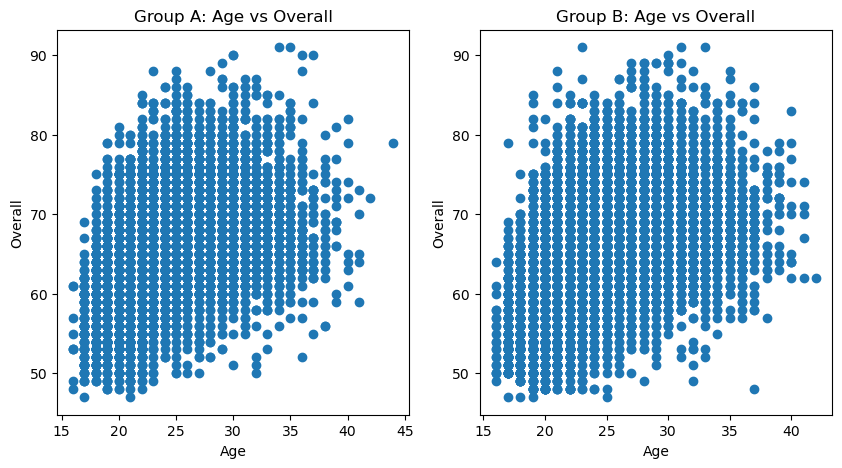

```python
# Your code here

fig, axes = plt.subplots(1, 2, figsize=(10, 5))

axes[0].scatter(groupA["Age"], groupA["Overall"])
axes[0].set_title("Group A: Age vs Overall")
axes[0].set_xlabel("Age")
axes[0].set_ylabel("Overall")

axes[1].scatter(groupB["Age"], groupB["Overall"])
axes[1].set_title("Group B: Age vs Overall")
axes[1].set_xlabel("Age")
axes[1].set_ylabel("Overall")

plt.show()
```